# SESAM Data Export

# Disclaimer

First Steps of getting started with exporting farm data and animal data from the breeding organisation database to be delivered to the SESAM server is described in this document.

# Resources and Material

The avaiable resources consist of template JSON files provided by Thomas Rahimi. From the provided JSON files, only the file called Partner.json is important for the dataexport.

# Inspect JSON File

To get a better understanding, the json file is read.

```r
s_sesam_data_export <- file.path(here::here(), "inst", "extdata", "Partner.json")
require(RJSONIO)
l_sesam <- fromJSON(s_sesam_data_export)
```

Unfortunately, the file contains certain placeholders and it does therefore not represent a valid JSON object. Therefore it cannot be read using the `RJSONIO` package. Reading it as a normal file and inspecting the header of the file leads to

```r
con_sesam <- file(description = s_sesam_data_export)
vec_sesam_data_export_skeleton <- readLines(con = con_sesam)
close(con = con_sesam)
head(vec_sesam_data_export_skeleton)
```

```
## [1] "{"                           "\"vvvo-farm-id\":"
## [3] "\t\"xxxx.xxxx.xxxx\","       "\"data-center\":\"LKV BW\","
## [5] "\"milkyield-testday\":"      "\t[{"
```

# Data Export - Mode of Operation

When SESAM moves into a testing- or a production-phase, farmers must be able to contact their breeding organisation (BO) to have their farm activated for the SESAM service. The activation of a farm should be available via the Webapplication of the BO. An example of how this might look like is shown in the diagram below.

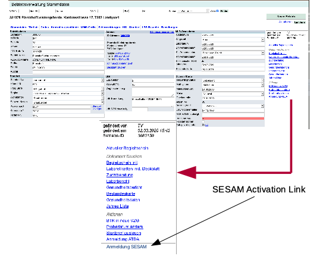

This activation requires certain data to be transfered from the BO-database to the SESAM server. This data-transfer is initially prepared by the SESAM-project team, but for the larger testing- or production phase, this data-tranfer must be implemented by the IT-group of Qualitas AG. As a consequence of this mode of operation, the data export functionality must be implemented in a PL/SQL-package that runs on the database. The package is called `pa_sesam`.

# Package Design

The package has one main entry point consisting of a public procedure called `SesamDataExport`. This procedure takes the farm-ID as parameter argument. The farm-ID is the primary key of the farm and it is also available from the web-application as it is shown on the farm-view. This will make it possible to trigger the data-transfer for the BO from the web-application. In production mode the functionality in `pa_sesam` will just collect the data from the farm and will send them to the sesam-server. Most likely, it will also be benefitial to write the data to be sent to a file such that it can be verified what was sent. On top of that, the package should have a debugging mode where more information is written to a logfile.

# Preparation

According to the structure given in Partner.json, the data to be transfered is divided into the following sections.

1. milkyield-testday
2. avg-milkyield-testday
3. indication
4. calving
5. insemination
6. master-data-cattle

The result of the data-export is one JSON object which is specific for one farm. We can say this because the farm-ID appears as a top-level record entry and hence all sub-records must relate to that single farm.

## Milkyield-testday

Milk performance characteristics for each cow on each testday are collected. Hence for each cow-testday combination we will obtain one record.

## Avg-milkyield-testday

This corresponds to the first data-records but averaged across all cows for every testday.

## Indication

Records about health-related indiciations

## Calving

Data on calving events

## Insemination

Data on insemination events. The problem with the insemination data is that there is more than one record per animal. Hence, when going through the list of animals we get a table of records which must be matched into a JSON-Array of single insemination records. Due to our database model, there is no secure way to link pregnancy testing and insemination records. There is a question on what level the insemination index must be computed. Should this be on a cow level or on a farm level. It probably makes most sense to show this at the cow level up until the current insemination event.

## Master-data-cattle

Master data on each cow. The components of the export of `master-data-cattle` are listed in the following table.

| JSON-Keys | DB-Field |
| --- | --- |
| animal-id | pa_ani.sTvdNrDataExport(pnaniid |
| name | ANINOM |
| num-of-shed | ??? |
| test-number | ??? |
| birthday | ANIDATENAISSANCE |
| breed | ANI_RACE_ID |
| sex | ANISEX |
| animal-id-father | IDPERE |
| animal-id-mother | IDMERE |
| date-of-removingfromstable | ANI_TVDABGANGSDATUM |
| reason-of-leaving | ANI_TVDABGANG_ID |

# Property Overview over all Exports

| Part | Table | Primary Key |
| --- | --- | --- |
| milkyield-testday | PESEE | IDPESEE |
| avg-milkyield-testday |  |  |
| indication | TR_MEDIDIAG | MEDD_ID |
| calving | LACTATION | IDLACTATION |
| insemination | INSEMINATION | IDINSEMINATION |
| master-data-cattle | ANIMAL | IDANIMAL |